# RNASeq DEA Tarea: Transcriptional Changes Associated with the Development Stage In Luminal Cells.

Giordana , Kristell Panta, Jason Lubega

12.Feb.2025

## **Introduction**

This dataset GSE60450 contains the gene expression profiles of luminal and basal cells from different developmental stages.  
Luminal and basal cells were harvested from the mammary glands of virgin, 18.5 day pregnant and 2 day lactating mice (2 mice per stage).

The original article was published [HERE](https://www.nature.com/articles/ncb3117)

## **Task**

We will perform a differential expression analysis (DEA) to identify the transcriptional changes associated with the development stage in **luminal cells.**

For the purpose of this assignment We will use the **lima-voom** (linear model) approach which requires that the data is normally distributed.

## **PLAN**

1. Data Preparation
2. Data filtering - filterByExpr()
3. Normalize data - using TMM
4. Design matrix definition - model.matrix()
5. Voom transformation - voom()
6. Lineal model fit - lmFit()
7. Statistic test - eBayes()

### **Data Preparation**

Set working directory  
Load libraries  
Input/Load data

```r
#Set working directory
setwd("C:/Users/Lenovo/MIB Assignments/NOTES/Bioinformatica/Bioinformatics Practice R/GSE60450 RNASeqDATA")
getwd()
```

```
[1] "C:/Users/Lenovo/MIB Assignments/NOTES/Bioinformatica/Bioinformatics Practice R/GSE60450 RNASeqDATA"
```

```r
#Load libraries
library(ggplot2)
library(limma)
suppressPackageStartupMessages(library(ComplexHeatmap))
library(edgeR)
library(reshape2)
library(org.Mm.eg.db)
#Input or load data

# Count matrix:
counts <- read.table("count_data_GSE60450.txt", sep=";")
View(counts)

# Sample metadata:
sample_metadata <- read.table("sample_metadata_GSE60450.txt", sep=";")
View(sample_metadata)

# Feature (genes) metadata:
gene_metadata <- read.table("gene_metadata_GSE60450.txt", sep=";", header = TRUE, fill = TRUE)
View(gene_metadata)
```

Our focus will be the luminal cells data. Therefore we will create a luminal cells only counts matrix.

```r
#Create counts_luminal only matrix

counts_luminal <- counts[,sample_metadata$cell_type=="luminal cell population"]
dim(counts_luminal) #27179   by  6
```

```
[1] 27179     6
```

```r
sample_metadata_luminal <- sample_metadata[sample_metadata$cell_type=="luminal cell population",]
View(sample_metadata_luminal)

View(counts_luminal)
```

We will also create an object to group later by the development stage (reference to objective)

```r
#group_dvst <- sample_metadata_luminal$developmental_stage
#table(group_dvst)

#changed due to downstream analysis (contrasts)
group_dvst <- factor(sample_metadata_luminal$developmental_stage)
levels(group_dvst)
```

```
[1] "18.5 day pregnancy" "2 day lactation"
[3] "virgin"
```

```r
table(group_dvst)
```

```
group_dvst
18.5 day pregnancy    2 day lactation             virgin
                 2                  2                  2
```

### **Data filtering:**

```r
dim(counts_luminal_filtered) #14582   by  6... FANTASTIC!
```

```
[1] 14582     6
```

#### **PAUSE: Show Me GRAPHICS!**

What do we have up to this point?

Use *par(mfrow)* to display all the graphics generated in a single row.

1.depth plot

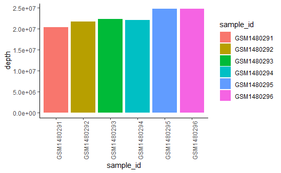

```r
#depth plot

lumcounts_to_plot <- data.frame(sample_id=colnames(counts_luminal_filtered),depth=colSums(counts_luminal_filtered))

View(lumcounts_to_plot)

library(ggplot2)

ggplot(lumcounts_to_plot,aes(x=sample_id, y=depth, fill=sample_id)) +
  geom_col() +
  theme_classic() +
  theme(axis.text.x = element_text(angle=90))
```

```r
NA
NA
```

2.Box plot (Distribution)

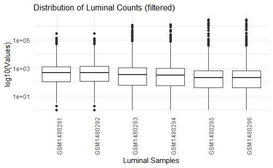

### **Normalise data:**

Now that data has been filtered, we will normalize it before using the linear model.

We will normalize this data using the **TMM method** as it compensates for more dominant genes unlike the CPM (total counts only).

The TMM method requires the *edgeR()* library and requires that data be transformed into a DGE list first.

```r
#Normalizing data using TMM

library(edgeR) #load required library for TMM

dge <- DGEList(counts = counts_luminal_filtered, group= group_dvst)

#?calcNormFactors

counts_luminal_normalized <- calcNormFactors(dge, method = "TMM")
```

**Question: Why have we normalized the way we have with *calcNormFactors* instead of manually with the code below?**

```r
counts_luminal_normalized <- normLibSizes(dge, method = "TMM")

counts_luminal_normalized <- cpm(counts_luminal_normalized, normalized.lib.sizes = TRUE)
counts_luminal_normalized_log2 <- log2(counts_luminal_normalized + 1)
```

**Answer:**

This is because the method we are using to call DEA (Differential Gene Expression) - **limma-voom** requires that data be fit onto a linear model.

calcNormFactors() and normLibSizes() are two TMM normalisation approaches with different outputs.

normLibSizes() normally used for data exploration as it normalises reads counts (lib.sizes). You would also have to perform cpm() in addition to this commmand.

calcNormFactors() accounts for the expression of each gene relative to the other and therefore is more suitable for DGE analysis.

For Voom transformation, the most suitable output is by calcNormFactors() which is then transformed and log2CPM is applied all within the voom() function.

### **Voom transformation:**

*voom()* stands for “variance modeling at the observational level.” It transforms raw RNA-seq counts into log2 counts-per-million (logCPM) while accounting for mean-variance relationships in the data.

RNA-seq count data is not *normally distributed*, however, **lmFit()** assumes normally distributed values therfore **voom()** estimates mean-variance relationships and transforms data to satisfy this assumption.

A **design matrix** of the microarray experiment is needed. It contains rows corresponding to samples and columns to coefficients to be estimated. And defines intergroup comparisons.

> How will the groups be compared?  
> Which should be the Control group? Do we need one?

```r
#normalised data transformation

#create design matrix (essential for voom() and lmFit())
#?model.matrix

#design_matrix <- model.matrix(~ group_dvst)
#colnames(design_matrix)

#** Outputs
#*[1] "(Intercept)"               "group_dvst2 day lactation"
#*[3] "group_dvstvirgin"


#WHO SHOULD BE THE CONTROL GROUP??? The model matrix chose the "18.5 day pregnancy" as the baseline group... Why not the virgin?

design_matrix <- model.matrix(~ 0 + group_dvst) #removes intercept
colnames(design_matrix)
```

```
[1] "group_dvst18.5 day pregnancy" "group_dvst2 day lactation"
[3] "group_dvstvirgin"
```

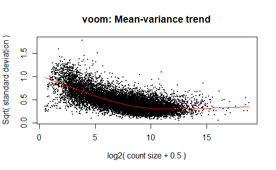

```r
#voom transformation
voom_transformed <- voom(counts_luminal_normalized, design_matrix, plot = TRUE)
```

Each dot represents a gene.  
X axis represents the log-tranformed gene expression.  
y axis represnts variance (sd)

**Take away:** Variance decreases with increasing gene expression (Red trend line).  
The higher the gene is expressed *the more sure* we are it is there.

### **Linear model fit:**

We will fit our voom-transformed data on the linear model and we will visualise our fitted data. For this we have to use the model matrix in the **lmFit()** function.

```r
#?lmFit

#create fit data
fit <- lmFit(voom_transformed, design =  design_matrix)

#class(fit) #fit is "MArrayLM" - MicroArray Linear Model
```

ADJUSTED MEAN?? METHOD USED (TMM, BONFERONI, HOLM, **BH**)

### **Statistic test:**

We will use the eBayes() test:

Given a linear model *fit* from *lmFit*, we can compute moderated t-statistics, moderated F-statistic, and log-odds of differential expression by empirical Bayes moderation of the standard errors towards a global value.

This function is used to rank genes in order of evidence for differential expression. It uses an empirical Bayes method to squeeze the genewise-wise residual variances towards a common value (or towards a global trend) (Smyth, 2004; Phipson et al, 2016).

```r
#?eBayes

fit_ebayes <- eBayes(fit)
```

### Output Matrix:

```r
#output matrix with fold change and adj.p-value<=0.05 = gene expression significant

#topTable function is part of the limma library
#We will use it to extract the output or result matrix

results_allgenes <- topTable(fit_ebayes, coef = ncol(design_matrix), number = Inf, adjust.method = "BH")

head(results_allgenes)
```

|  | logFC | AveExpr | t | P.Value | adj.P.Val | B |
| --- | --- | --- | --- | --- | --- | --- |
| 100042008 | 9.523280 | 9.213292 | 169.9477 | 3.094096e-15 | 1.307028e-12 | 24.18604 |
| 13205 | 9.970984 | 10.040929 | 172.0015 | 2.816701e-15 | 1.307028e-12 | 24.15961 |
| 13627 | 11.690352 | 11.524902 | 189.0841 | 1.343325e-15 | 1.307028e-12 | 24.14876 |
| 56040 | 9.311335 | 9.124844 | 165.8277 | 3.748645e-15 | 1.307028e-12 | 24.11663 |
| 55949 | 9.302048 | 9.215915 | 165.7043 | 3.770524e-15 | 1.307028e-12 | 24.11485 |
| 13629 | 11.261092 | 11.217519 | 181.5542 | 1.845812e-15 | 1.307028e-12 | 24.10785 |

coef: Specifies condition to compare.  
number = Inf, Retuens all genes.  
adjust.method = “BH”, Benjamini-Hochberg to adjust p values.

**SAVING RESULTS**

As txt file *write.table()* and as rds *saveRDS()*

```r
write.table(results_allgenes, file="limma_differential_expr_results.txt", sep="\t", quote=FALSE)

#?saveRDS
saveRDS(results_allgenes, file="DEA_limma_GSE60450.rds")
```

**Significantly DIFFERENTIALY EXPRESSED GENES**

These will be saved as *sigGenes*

```r
sigGenes <- results_allgenes[results_allgenes$adj.P.Val<=0.05 & results_allgenes$logFC>0.58, ] #it is the rows that we are filtering based on the defined criteria but we want all columns to come back.

dim(sigGenes)
```

```
[1] 12144     6
```

●○●○●○●○●

**TOP 50 Differentially Expressed Genes**

For this we have to first organise the results *by the adjusted p values.*

```r
sigGenes <- sigGenes[order(sigGenes$adj.P.Val), ] #from most significant to least significant

t50_sigGenes <- head(sigGenes, n=50)

t50_sigGenes <- gene_metadata[rownames(t50_sigGenes), c("SYMBOL", "GENENAME")]

t50_sigGenes
```

|  | SYMBOL | GENENAME |
| --- | --- | --- |
| NA | NA | NA |
| 13205 | Ddx3x | DEAD box helicase 3, X-linked |
| 13627 | Eef1a1 | eukaryotic translation elongation factor 1 alpha 1 |
| 56040 | Rplp1 | ribosomal protein lateral stalk subunit P1 |
| 55949 | Eef1b2 | eukaryotic translation elongation factor 1 beta 2 |
| NA.1 | NA | NA |
| NA.2 | NA | NA |
| 15516 | Hsp90ab1 | heat shock protein 90 alpha (cytosolic), class B member 1 |
| 67891 | Rpl4 | ribosomal protein L4 |
| NA.3 | NA | NA |

[output cut: 40 more lines]

As seen above our gene metadata is not fully annotated therefore we will annotate it to have all genes identified.  
For that we will use the *library(org.Mm.eg.db)* which contains all the information related with the Mus musculus genome.

```r
library(org.Mm.eg.db)
#columns(org.Mm.eg.db)

gene_metadata_annotated <- select(org.Mm.eg.db,keys=rownames(gene_metadata),columns=c("ENTREZID","SYMBOL","GENENAME"))
#View(gene_metadata_annnotated)
#This ommited the Length column but filled the symbols and gene names
#We can now use this to identify the missing columns
selection <- head(sigGenes, n=50)

t50_sigGenes_complete <- gene_metadata_annotated[gene_metadata_annotated$ENTREZID %in% rownames(head(sigGenes, n=50)), c("SYMBOL", "GENENAME")]
```

```r
t50_sigGenes_complete
```

|  | SYMBOL | GENENAME |
| --- | --- | --- |
| 57 | Rpl7 | ribosomal protein L7 |
| 275 | Sf3b1 | splicing factor 3b, subunit 1 |
| 351 | Eef1b2 | eukaryotic translation elongation factor 1 beta 2 |
| 667 | Hdlbp | high density lipoprotein (HDL) binding protein |
| 1303 | Hnrnpu | heterogeneous nuclear ribonucleoprotein U |
| 2601 | Rpl15 | ribosomal protein L15 |
| 3343 | Brd2 | bromodomain containing 2 |
| 3415 | Prrc2a | proline-rich coiled-coil 2A |
| 3620 | Hsp90ab1 | heat shock protein 90 alpha (cytosolic), class B member 1 |
| 3734 | Csnk1a1 | casein kinase 1, alpha 1 |

[output cut: 13 more lines]

### **Result Visualization:**

**Principal Component**  
To see developmental stage differences in Samples.

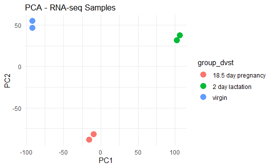

```r
pca <- prcomp(t(voom_transformed$E), scale. = TRUE)
pca_data_to_plot <- data.frame(PC1 = pca$x[,1], PC2 = pca$x[,2], group = group_dvst)

ggplot(pca_data_to_plot, aes(x = PC1, y = PC2, color = group_dvst)) +
  geom_point(size=4) +
  theme_minimal() +
  labs(title = "PCA - RNA-seq Samples", x = "PC1", y = "PC2")
```

**Volcano plot**

Biological relevance vs Statistical significance.

[figure not shown]

```r
#Volcano Plot
ggplot(results_allgenes, aes(x = logFC, y = -log10(adj.P.Val))) +
  # All genes = BLACK (These don't change)
  geom_point(color = "black", alpha = 0.3) +

  #Overexpressed genes = RED
  geom_point(data=results_allgenes[results_allgenes$logFC > 0.58 & results_allgenes$adj.P.Val <= 0.05,],
             aes(x = logFC, y = -log10(adj.P.Val)), color="red", alpha = 0.7) +

  #Under expressed genes = BLUE
  geom_point(data=results_allgenes[results_allgenes$logFC < -0.58 & results_allgenes$adj.P.Val <= 0.05,],
             aes(x = logFC, y = -log10(adj.P.Val)), color="blue", alpha = 0.7) +

#ref lines
  geom_hline(yintercept = -log10(0.05), linetype = "dashed", color = "blue") +
  geom_vline(xintercept = c(0.58, -0.58), linetype = "dashed", color = "gray") +

  theme_minimal() +

  labs(title = "Volcano Plot - Diferential Expression",
       x = "Log2 Fold Change",
       y = "-Log10 P-value")
```

x axis = *whether a expression of gene changes in between groups*

y axis = *whether the gene change is significant between groups.*

## **Contrasts with a Heatmap**

Top 50 genes differentially expressed genes in each development stage are visualized below with a heatmap.

This was easier to do in regards to statistical methods of comparing group levels against each other.

Visual representation of this data requires that a **z_score** be obtained from the voom transformed (normalised data), this sets the mean of each sample to 0 and enables us to see the minor changes in gene expression visually (both above and below zero)

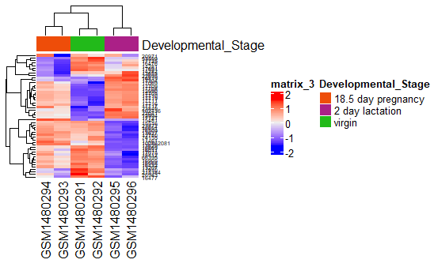

For each of the developmental stages (samples), It is possible to extract overexpressed genes and underexpressed genes by using a selection criteria of z> 1.5 and z< -1.5 respectively.

Alternativeley, contrasts can be made to do the same.

## **Conclusions**

**Acknowledgements**

The commented scripts by Teacher Nuria were helpful in reusing the code. We also used chatGPT to debug the code and understand arguments and for clarity of some concepts.

## **References**

1. *Fu, N. Y., Rios, A. C., Pal, B., Soetanto, R., Lun, A. T. L., Liu, K., Beck, T., Best, S. A., Vaillant, F., Bouillet, P., Strasser, A., Preiss, T., Smyth, G. K., Lindeman, G. J., & Visvader, J. E. (2015). EGF-mediated induction of Mcl-1 at the switch to lactation is essential for alveolar cell survival. Nature Cell Biology 2014 17:4, 17(4), 365–375. https://doi.org/10.1038/ncb3117*
2. *GSE60450 (GEO data) - https://www.ncbi.nlm.nih.gov/geo/query/acc.cgi?acc=GSE60450*
3. *limma - voom ( https://rpubs.com/jrgonzalezISGlobal/transcriptomic_analyses )*
4. *edgeR (https://www.bioconductor.org/packages/devel/bioc/vignettes/edgeR/inst/doc/edgeRUsersGuide.pdf, points 2.10, 2.11)*
5. *Identifying differentially expressed genes using linear models (part 1) - https://gtk-teaching.github.io/Microarrays-R/06-DifferentialGeneExpression/index.html*
6. *Use par mfrow to split screen - https://r-graph-gallery.com/71-split-screen-with-par-mfrow.html#:~:text=The%20par()%20function%20allows%20to%20set%20parameters%20to%20the,rows%20and%20number%20of%20columns.*
7. *Phipson B, Lee S, Majewski IJ, Alexander WS, Smyth GK (2016). Robust hyperparameter estimation protects against hypervariable genes and improves power to detect differential expression. Annals of Applied Statistics 10, 946-963. doi:10.1214/16-AOAS920*
8. *Smyth GK (2004). Linear models and empirical Bayes methods for assessing differential expression in microarray experiments. Statistical Applications in Genetics and Molecular Biology Volume 3, Issue 1, Article 3. doi:10.2202/1544-6115.1027. See also the Preprint Version https://gksmyth.github.io/pubs/ebayes.pdf incorporating corrections to 30 June 2009.*
9. *OpenAI. (2025). ChatGPT (Feb 14 version) [Large language model]. Retrieved from https://openai.com*